# CoSIBS career talk

6/24/2022

## Outline

- My career path
- Some interesting projects I’ve worked on
- Things I’ve learned
- Q&A

## Undergraduate and graduate studies in biology

- BA Biology and MS in Evolutionary and Population Biology, George Mason University
- Worked with scientists at the Nature Conservancy to study patterns of plant communities and invasive species in the forests along the Potomac River

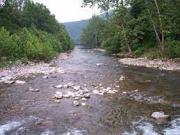

## Graduate studies in environmental science

- PhD program in Environmental Science at Duke University
- My research used diatoms to reconstruct the ecological history of Florida Bay

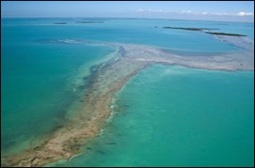

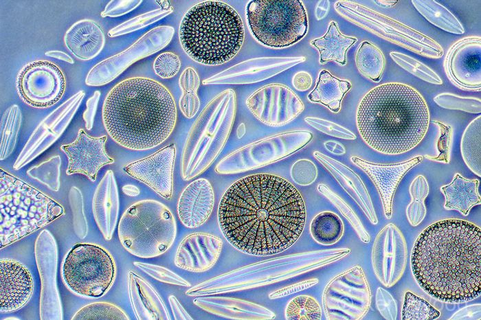

## My path to biostatistics

- While at Duke, I took graduate courses in statistics at North Carolina State University
- I was feeling less certain that I wanted to specialize in one particular research question, and statistics appealed to me as a tool to answer diverse questions
- I left my graduate program early with an MA and took a couple of years off
- Moved to the DC area and took a job as a Research Associate at the George Washington University Biostatistics Center

[figure not shown]

## Working at a “coordinating center”

- Coordinating centers are established for multi-center clinical trials
- They are responsible for advising on study design and the analytic plan, all aspects of data management, performing the statistical analysis, manuscript writing, and general oversight and communications
- Statisticians work as part of large teams along with programmers, content matter experts, administrators, etc.
- These are generally large projects with 1-2 years of planning prior to study start and 3-4 years of data collection
- Analysis usually begins when sufficient baseline data are collected

## The TODAY study

- The TODAY study was a clinical trial to compare 3 treatments for type 2 diabetes in children and adolescents
- Type 2 diabetes (T2D) used to be known as adult-onset diabetes and results from a combination of genetic and lifestyle factors (overweight, inactivity)
- The incidence of T2D among youth is increasing.https://www.cdc.gov/diabetes/research/reports/children-diabetes-rates-rise.html

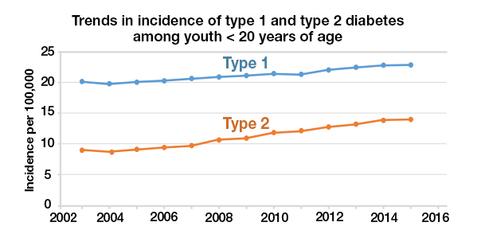

## T2D in youth

Lawrence et al. 2021, JAMA.

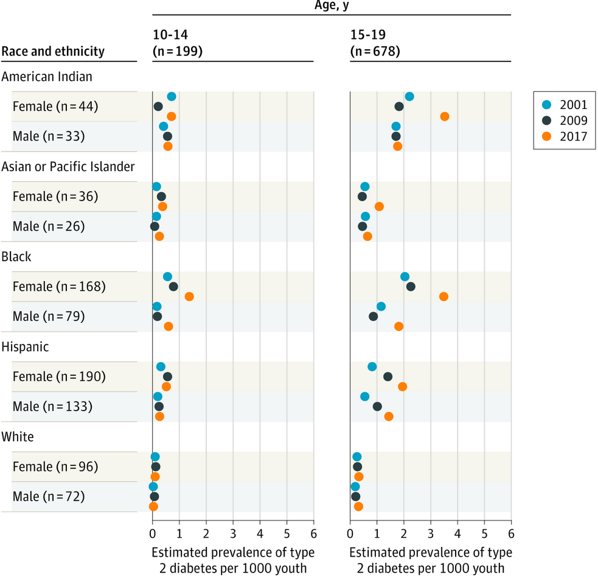

## T2D in youth

TODAY Study Group 2021, NEJM.

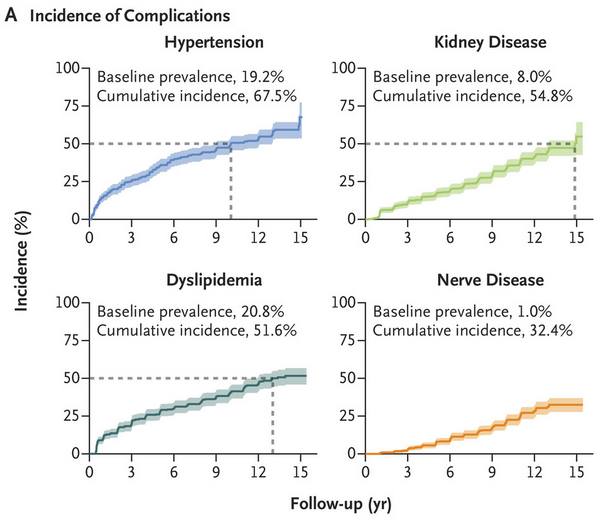

## The TODAY study results

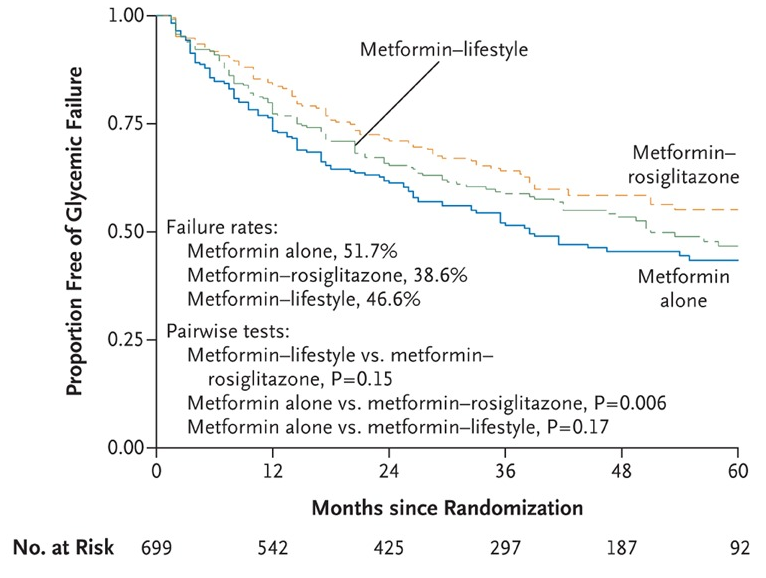

## Things I learned at GWU

- Formulating a question/hypothesis that can be answered by a statistical test
- Designing data collection instruments
- Writing code as part of a team
- Communicating statistical concepts to non-statisticians
- Writing articles for biomedical journals

## Graduate work at GWU and the University of Colorado

- While at GWU, I took graduate courses in math, programming, and statistics
- I was accepted into the PhD program in statistics at GWU and also by the PhD program in biostatistics at CU
- After visiting CU, I thought the faculty were more passionate about teaching, while still very active in research
- I also thought the curriculum at CU better integrated statistics and biology
- I continued working at GWU (remotely) while I was in graduate school at CU
- My dissertation was on methods for analyzing longitudinal outcomes in clinical trials prior to being completely observed

## Job at the University of Colorado

- When I graduated with my PhD, I was offered a faculty position at GWU, but I would have to move back to DC
- I decided to look for a position that would allow me to stay in Colorado
- In 2013, I started working at CU as an Assistant Professor and Associate Director of the Child Health Biostatistics Core
- The mission of the CHBC is to collaborate with child health researchers on campus in all aspects of study design and statistical analysis
- I was appointed as Acting Director of the CHBC in 2018 and as Director in 2020
- I work with many of the same investigators on the TODAY study

## Measuring changes in glucose rate of appearance in patients with diabetes

- In people with diabetes, hyperglycemia can result from inadequate insulin secretion and insulin resistance
- The degree of insulin resistance can be assessed by the gold-standard hyperinsulinemic euglycemic clamp
- As insulin ↑, the liver and muscles stop producing glucose and adipose tissue stops releasing fatty acids
- The amount of insulin required to stop the production is a measure of insulin sensitivity

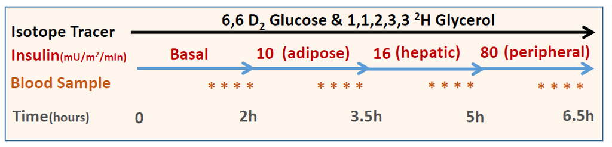

## Measuring changes in glucose rate of appearance in patients with diabetes

- The summary measure from the clamp is the amount of insulin required to suppress glucose production 50%
- In people with diabetes who are taking insulin, we can’t measure this accurately

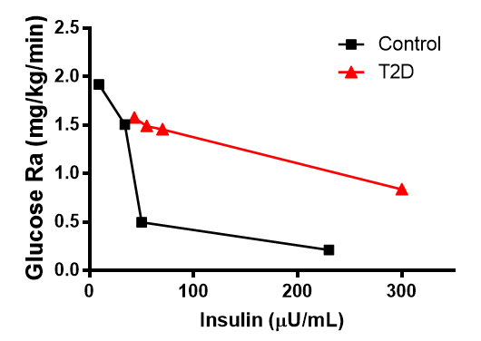

## Measuring changes in glucose rate of appearance in patients with diabetes

- We used mixed-effects models to examine changes in glucose Ra over time and compared this to the standard method
- We also used insulin as the independent variable to account for within participant variability in achieved insulin levels

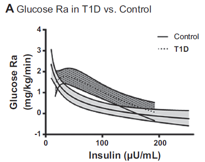

Pyle et al. 2016, AJP Endo Metab.

## SMART designs

- Weight loss management study (Pfammatter et al. 2019, Contemp Clin Trials)

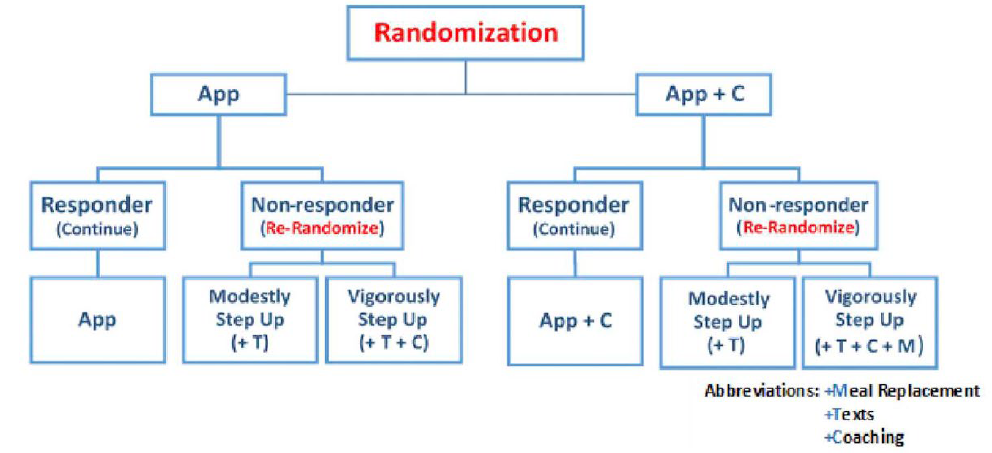

## SMART designs

- SMARTs utilize a factorial design in a sequential setting to efficiently test the main effects of the treatments
- Can also test how the interventions interact
- Statistical challenges
  - Power calculations
  - Handling missing data and loss to follow up
  - Interim monitoring
  - Use of Q-learning algorithm to build an optimal sequence of interventions

## TODAY study proteomics and metabolomics

- With TODAY study investigators, I have a grant to identify protein and metabolite signatures of complications of youth-onset T2D using traditional statistical methods as well as machine learning methods
  - Linear models with moderated t-statistics
  - Sparse partial least-squares discriminant analysis (sPLS-DA)
  - Gene Set Enrichment Analysis
  - Boosted Cox regression
- We are also collaborating with an applied mathematician, Anita Layton, at the University of Waterloo to create deep learning models

## TODAY study proteomics and metabolomics

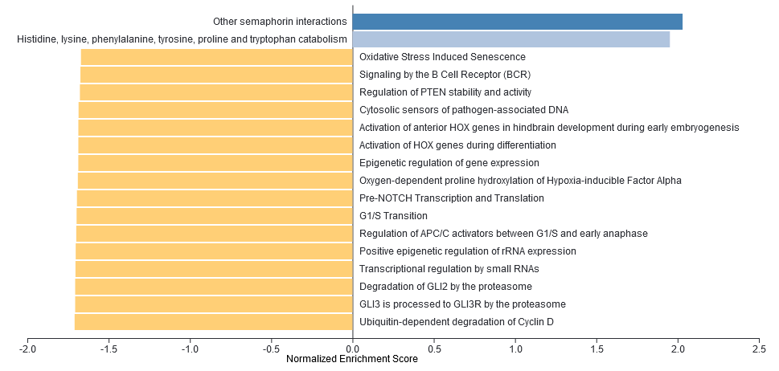

## Phenotypes of diabetic kidney disease

- Because of my collaborations with the TODAY study and other national study groups, I have access to rich longitudinal datasets related to diabetes and its complications
- This includes data from a longitudinal study of Pima Indian individuals that started in the 1960s
- We plan to harmonize the data from several of these studies, including proteomics and metabolomics, and then to use unsupervised cluster analysis to identify phenotypes of DKD
- Once clusters are identified, we can validate the phenotypes against kidney biopsy data in a subset of participants

## How is my CU job different from GWU?

- GWU
  - Large studies with large budgets and teams
  - Extremely careful data collection and cleaning
  - Long lead time for publications
  - Deep focus on 1 or 2 studies
- CU
  - Lots (!) of projects, sometimes un/underfunded
  - Smaller budgets, smaller teams, less time for data cleaning
  - Rapid time to publication
  - Smaller studies, but often participants are deeply phenotyped using gold-standard methods

## What do I do on a daily basis?

- Consultation and project meetings (Zoom!)
- Writing grants
- Writing code to do data cleaning and analysis
- Collaborating on manuscripts and abstracts
- Education (graduate students, medical students, residents, fellows, etc.)
- Reading about statistical methods and keeping up to date
- Managing other statisticians in the core
- Administrative tasks (budgets, talking to investigators about new projects, University and hospital committees, etc.)

## Things I’ve learned

- Keep learning new methods and skills, as well as subject matter content
- Sharpen your coding skills
- Writing and communication are important, no matter what area of statistics you work in
- Work with people you like
- There are lots of different types of statistics jobs, even within academia